# Peer-graded Assignment

## Testing the smaller model

Now we see how well the smaller model works on the test holdout set.

```r
smallpred <- predict(smallmodel, smalltestx)
confusionMatrix(smallpred, smalltesty)
```

```
## Confusion Matrix and Statistics
##
##           Reference
## Prediction    A    B    C    D    E
##          A 1115    1    1    0    0
##          B    1  756    0    0    0
##          C    0    2  681    3    0
##          D    0    0    2  640    1
##          E    0    0    0    0  720
##
## Overall Statistics
##
##                Accuracy : 0.9972
##                  95% CI : (0.995, 0.9986)
##     No Information Rate : 0.2845
##     P-Value [Acc > NIR] : < 2.2e-16
##
##                   Kappa : 0.9965
##  Mcnemar's Test P-Value : NA
##
## Statistics by Class:
##
##                      Class: A Class: B Class: C Class: D Class: E
## Sensitivity            0.9991   0.9960   0.9956   0.9953   0.9986
## Specificity            0.9993   0.9997   0.9985   0.9991   1.0000
## Pos Pred Value         0.9982   0.9987   0.9927   0.9953   1.0000
## Neg Pred Value         0.9996   0.9991   0.9991   0.9991   0.9997
## Prevalence             0.2845   0.1935   0.1744   0.1639   0.1838
## Detection Rate         0.2842   0.1927   0.1736   0.1631   0.1835
## Detection Prevalence   0.2847   0.1930   0.1749   0.1639   0.1835
## Balanced Accuracy      0.9992   0.9979   0.9970   0.9972   0.9993
```

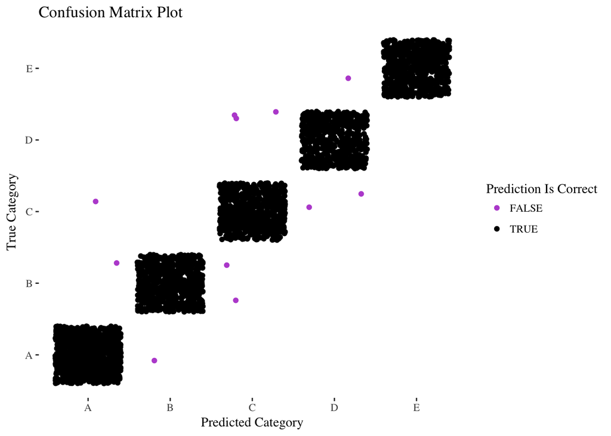

```r
g <- ggplot(data = data.frame(pred = smallpred, True=smalltesty,
misclas = (smallpred==smalltesty)))

g + geom_jitter(aes(x = pred, y = True, col=misclas)) + theme_tufte() +
    xlab('Predicted Category') + ylab('True Category') +
ggtitle('Confusion Matrix Plot') + labs(color='Prediction Is Correct') +
    scale_colour_manual(values = c('mediumorchid', 'black'))
```

There seems to be no pattern in our prediction errors. We are now ready to train a full-size model and use it to predict on our original test set and answer all questions on the quiz.

## Training the Full Model

We utilize the parallel and doParallel packages to quicken the training process. The model has previously been saved into the file ‘rfMOdel.rds’ and is loaded from there instead of training, but the code for the model is availiable below.

This model has previously been trained and saved into a file, but the code follows for reproducibility.

```r
#library(parallel)
#library(doParallel)
#cluster <- makeCluster(detectCores() - 1)
#registerDoParallel(cluster)
#model <- train(x = xtrain, y = ytrain, method = 'rf',
#               trControl = fitSettings)
#saveRDS(model, 'rfModel.rds')
#stopCluster(cluster)
#registerDoSEQ()

model <- readRDS('rfModel.rds')
```

## Testing the Full Model

Now we apply the same pre-processing to the testing data, as we did to the training data, after which we find our predictions.

```r
model
```

```
## Random Forest
##
## 19622 samples
##    26 predictor
##     5 classes: 'A', 'B', 'C', 'D', 'E'
##
## No pre-processing
## Resampling: Cross-Validated (15 fold)
## Summary of sample sizes: 18314, 18314, 18313, 18314, 18314, 18314, ...
## Resampling results across tuning parameters:
##
##   mtry  Accuracy   Kappa
##    2    0.9859345  0.9822053
##   14    0.9823165  0.9776325
##   26    0.9774240  0.9714399
##
## Accuracy was used to select the optimal model using  the largest value.
## The final value used for the model was mtry = 2.
```

```r
xtest <- predict(preObj, test)
pred <- predict(model, xtest)
pred
```

```
##  [1] B A A A A E D B A A B C B A E E A B B B
## Levels: A B C D E
```

# Summary

In this assignment I read and cleaned data meassured by motion sensors mounted on various parts of participants’ bodies. This data was then used to predict the manner in which they did certain exercises. After cleaning the data and preprocessing it by centering, scaling, and reducing its dimensions, random forests was the preferred model. There was little need for interpretability of the model and no need for major scalability, and RF is an extremely accurate algorithm that sacrifices both of those perks.